# Predição de Votação de Deputados

Dandara Sousa

11 de dezembro de 2017

Primeiramente, vamos inicializar nosso dataset. Nele contém dados dos deputados e a quantidade de votos. Como podemos ver mais abaixo há muita informação faltando e para não compremeter nossa predição iremos dar à essas partes o valor de zero.

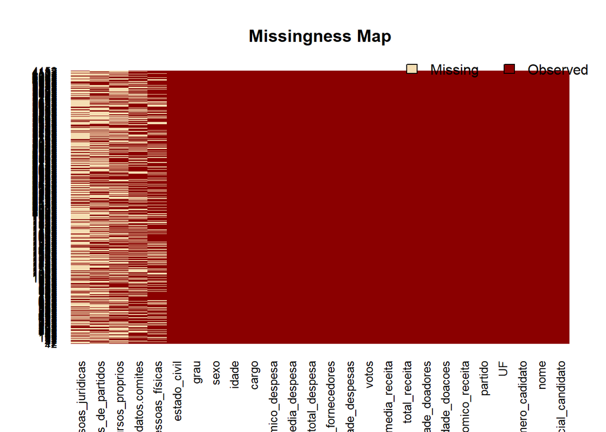

```r
dataVotos <- read.csv("eleicoes2014.csv", encoding = "latin1")
missmap(dataVotos)
```

```r
dataVotos <- dataVotos %>%
  mutate(
      recursos_de_pessoas_físicas = replace(recursos_de_pessoas_físicas,is.na(recursos_de_pessoas_físicas),0),
      recursos_de_pessoas_juridicas= replace(recursos_de_pessoas_juridicas,is.na(recursos_de_pessoas_juridicas),0),
      recursos_de_outros_candidatos.comites= replace(recursos_de_outros_candidatos.comites,is.na(recursos_de_outros_candidatos.comites),0),
      recursos_de_partidos = replace(recursos_de_partidos, is.na(recursos_de_partidos), 0),
      recursos_proprios = replace(recursos_proprios, is.na(recursos_proprios),0)
  )
```

O próximo passo para deixar os dados apropriados para nossa análise é excluir variáveis que previamente vimos que não influenciam para nosso caso.

```r
dataVotos.ajustado <- dataVotos %>%
  select(-nome, -sequencial_candidato, -numero_cadidato, -cargo, -setor_economico_despesa, -setor_economico_receita,  -partido, -UF)
```

*Separação em dados e treino:*  
Agora, vamos preparar nossos dados para nosso real objetivo hoje. Primeiro, vamos dividir nossos dados em dados para treino e dados para teste. Os dados para treino servirão para preparar nosso modelo para o teste (que intuitivamente será com os dados para testes).

```r
smp_size <- floor(.7*nrow(dataVotos.ajustado))
set.seed(123)
train_id <- sample(seq_len(nrow(dataVotos.ajustado)), size = smp_size)

dataVotos.treino <- dataVotos.ajustado[train_id,]
dataVotos.teste <- dataVotos.ajustado[-train_id,]
```

*Reamostragem:*  
Nesse momento vamos fazer a reamostragem dos nossos dados e, em seguida, vamos começar os modelos de regressão.

```r
dataVotos.control <- trainControl(method = "repeatedcv",
                                  number = 5,
                                  repeats = 5
                                  )
```

**Tunando (usando validação cruzada):**

1. um modelo de regressão Ridge  
   *modelo e cross validation:*

```r
data.model.ridge <- train(votos ~.,
                    data = dataVotos.treino,
                    method = "ridge"
                    )
model.cv.ridge <- train(votos ~ .,
               data = dataVotos.treino,
               method = "ridge",
               trControl = dataVotos.control,
               preProcess = c('scale', 'center', 'nzv'),
               tuneLength = 5
               )
model.cv.ridge
```

```
## Ridge Regression
##
## 2906 samples
##   17 predictor
##
## Pre-processing: scaled (20), centered (20), remove (5)
## Resampling: Cross-Validated (5 fold, repeated 5 times)
## Summary of sample sizes: 2323, 2325, 2325, 2325, 2326, 2323, ...
## Resampling results across tuning parameters:
##
##   lambda  RMSE      Rsquared   MAE
##   0e+00   36972.67  0.4221552  12423.46
##   1e-04   36824.15  0.4263026  12388.51
##   1e-03   36701.08  0.4290081  12362.05
##   1e-02   36417.04  0.4342260  12302.95
##   1e-01   36235.27  0.4418153  12343.66
##
## RMSE was used to select the optimal model using the smallest value.
## The final value used for the model was lambda = 0.1.
```

2. um modelo de regressão Lasso  
   *modelo e cross validation:*

```r
data.model.lasso <- train(votos ~.,
                    data = dataVotos.treino,
                    method = "lasso")
model.cv.lasso <- train(votos ~ .,
               data = dataVotos.treino,
               method = "lasso",
               trControl = dataVotos.control,
               preProcess = c('scale', 'center', 'nzv'),
               tuneLength = 5
               )
model.cv.lasso
```

```
## The lasso
##
## 2906 samples
##   17 predictor
##
## Pre-processing: scaled (20), centered (20), remove (5)
## Resampling: Cross-Validated (5 fold, repeated 5 times)
## Summary of sample sizes: 2325, 2323, 2325, 2326, 2325, 2325, ...
## Resampling results across tuning parameters:
##
##   fraction  RMSE      Rsquared   MAE
##   0.1       37039.90  0.4225067  13376.41
##   0.3       36806.54  0.4299437  12424.53
##   0.5       36844.29  0.4315425  12369.15
##   0.7       36856.76  0.4315770  12373.89
##   0.9       36879.66  0.4312326  12381.82
##
## RMSE was used to select the optimal model using the smallest value.
## The final value used for the model was fraction = 0.3.
```

3. um modelo KNN. *modelo e validacao:*

```r
data.model.knn <- train(votos ~.,
                    data = dataVotos.treino,
                    method = "knn"
                    )
model.cv.knn <- train(votos ~ .,
               data = dataVotos.treino,
               method = "knn",
               trControl = dataVotos.control,
               preProcess = c('scale', 'center', 'nzv'),
               tuneLength = 5
               )
model.cv.knn
```

```
## k-Nearest Neighbors
##
## 2906 samples
##   17 predictor
##
## Pre-processing: scaled (20), centered (20), remove (5)
## Resampling: Cross-Validated (5 fold, repeated 5 times)
## Summary of sample sizes: 2324, 2325, 2324, 2325, 2326, 2326, ...
## Resampling results across tuning parameters:
##
##   k   RMSE      Rsquared   MAE
##    5  34713.17  0.4631695  10832.98
##    7  34048.94  0.4822750  10516.52
##    9  33642.01  0.4934559  10326.20
##   11  33436.16  0.5001567  10255.74
##   13  33269.43  0.5059338  10173.18
##
## RMSE was used to select the optimal model using the smallest value.
## The final value used for the model was k = 13.
```

Usamos uma reamostragem com validação cruzada como vimos acima e os resultados foram:

| . | Ridge | Lasso | KNN |
| --- | --- | --- | --- |
| final value[^1] | 0.1 | 0.3 | 13 |
| RSME | 36235.27 | 36806.54 | 33269.43 |
| Rsquared | 0.4418153 | 0.4299437 | 0.5059338 |
| MAE | 12343.66 | 12424.53 | 10173.18 |

**Comparação em termos do erro RMSE de validação cruzada.** Para termos uma noção melhor do poder preditivo com nossos dados de teste, temos:

```r
rmse <- function(err) {
    sqrt(mean(err^2))
}

ridge.pred <- predict(model.cv.ridge, dataVotos.teste)
ridge.rmse <- rmse(ridge.pred - dataVotos.teste$votos)

lasso.pred <- predict(model.cv.lasso, dataVotos.teste)
lasso.rmse <- rmse(lasso.pred - dataVotos.teste$votos)

ridge.rmse
```

```
## [1] 28887.08
```

```r
lasso.rmse
```

```
## [1] 28251.47
```

**As variáveis mais importantes segundo o modelo de regressão Ridge e Lasso**

Para a importância das variáveis de cada modelo, vamos observar os seguintes gráficos e já modificar de acordo com a não importância de variáveis do melhor modelo.

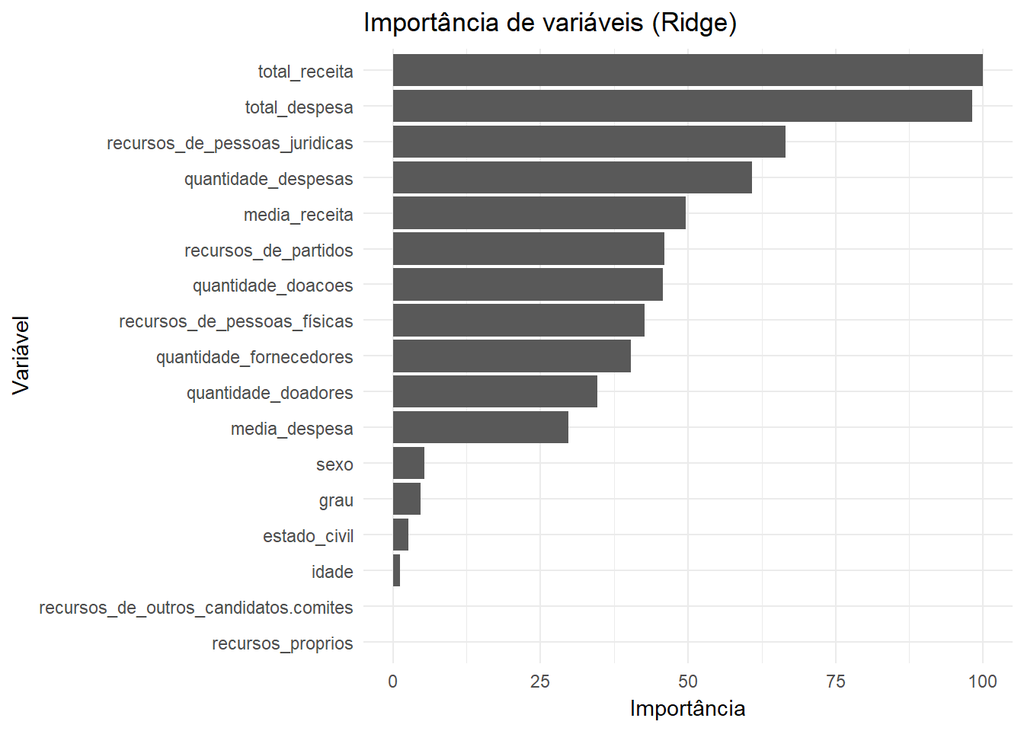

```r
ridge <- ggplot(varImp(model.cv.ridge)) +
  labs(title="Importância de variáveis (Ridge)", x="Variável", y="Importância")

ridge
```

Com Ridge,as variáveis de `recursos_de_outros_candidatos.comites` e `recursos_proprios` não tiveram importância. Assim como mais abaixo veremos que em Lasso elas também não são importantes.

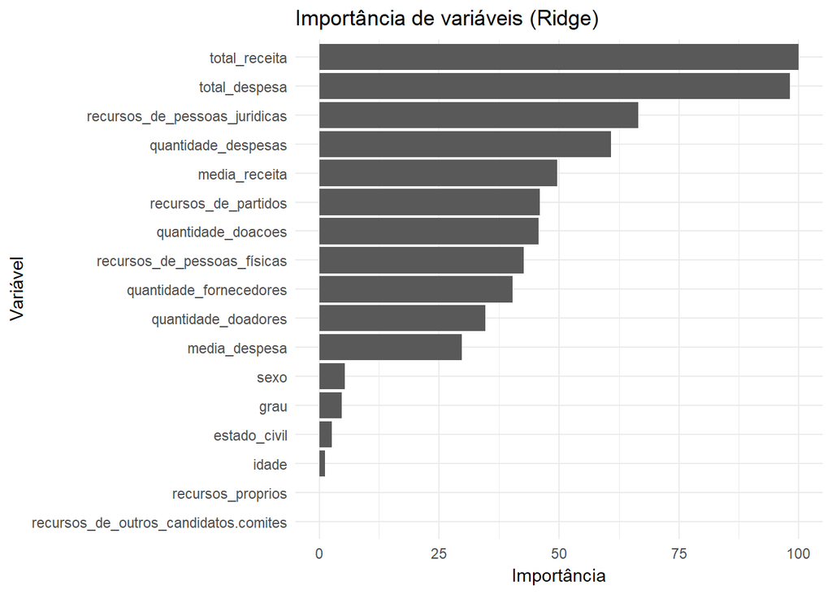

```r
lasso <- ggplot(varImp(model.cv.lasso)) +
  labs(title="Importância de variáveis (Ridge)", x="Variável", y="Importância")
lasso
```

```r
dataVotos.treino.lasso <- dataVotos.treino %>%
  select(-recursos_de_outros_candidatos.comites,recursos_proprios)
```

**Re-treino do melhor modelo (usando os melhores valores de parâmetros encontrados em todos os dados, sem usar validação cruzada)**

Um pequeno resumo do que veremos mais abaixo:

[output not shown]

É possível então perceber que o RSME do nosso dado de treino está próximo ao completo.

```r
data.model.lasso <- train(votos ~.,
                    data = dataVotos.treino.lasso,
                    method = "lasso"
                    )
model.cv.lasso <- train(votos ~ .,
               data = dataVotos.treino.lasso,
               method = "lasso",
               preProcess = c('scale', 'center', 'nzv'),
               tuneLength = 5
               )
lasso.pred <- predict(model.cv.lasso, dataVotos.treino)
lasso.rmse <- rmse(lasso.pred - dataVotos.treino$votos)
lasso.rmse
```

```
## [1] 36153.43
```

O valor do RMSE foi menor que o anterior `RSME = 36153.43`. De forma geral, a mudança para com a validação cruzada é muito pequena porque esse método não altera o resultado dos testes.

Agora, com os dados de teste:

```r
dataVotos.lasso <- dataVotos.teste %>%
  select(-recursos_de_outros_candidatos.comites,recursos_proprios)

data.model.lasso <- train(votos ~.,
                    data = dataVotos.lasso,
                    method = "lasso"
                    )
model.cv.lasso <- train(votos ~ .,
               data = dataVotos.lasso,
               method = "lasso",
               preProcess = c('scale', 'center', 'nzv'),
               tuneLength = 5
               )
lasso.pred <- predict(model.cv.lasso, dataVotos.teste)
lasso.rmse <- rmse(lasso.pred - dataVotos.teste$votos)
lasso.rmse
```

```
## [1] 24216.11
```

E, com todos os dados:

```r
dataVotos.lasso <- dataVotos.ajustado %>%
  select(-recursos_de_outros_candidatos.comites,recursos_proprios)

data.model.lasso <- train(votos ~.,
                    data = dataVotos.lasso,
                    method = "lasso"
                    )
model.cv.lasso <- train(votos ~ .,
               data = dataVotos.lasso,
               method = "lasso",
               preProcess = c('scale', 'center', 'nzv'),
               tuneLength = 5
               )
lasso.pred <- predict(model.cv.lasso, dataVotos.ajustado)
lasso.rmse <- rmse(lasso.pred - dataVotos.ajustado$votos)
lasso.rmse
```

```
## [1] 32964.78
```

[^1]: Em Ridge o final value usado é o melhor lambda, em Lasso é fraction e com KNN é k.